# Tree-based Regression

```r
library(tidyverse)
library(data.table)
library(rpart)
library(rattle)
library(wooldridge)
```

## Regression tree

### What is it?

Here is an example of regression tree to explain logged salary (`lsalary`) using the `mlb1` data from the `wooldridge` package.

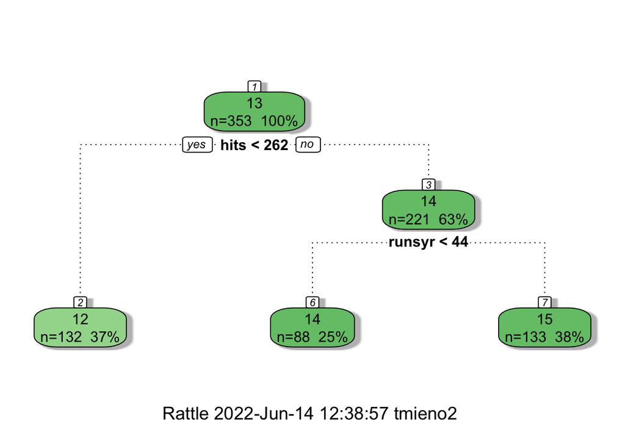

```r
#=== get mlb1 data (from wooldridge) ===#
data(mlb1)

#=== build a simple tree ===#
simple_tree <-
  rpart(
    # lsalary ~ . - salary,
    lsalary ~ hits + runsyr,
    data = mlb1,
    control = rpart.control(minsplit = 200)
  )

fancyRpartPlot(simple_tree)
```

Here is how you read the figure. At the first node, all the observations belong to it ($n=353$) and the estimate of `lsalary` is 13. Now, the whole datasets are split into two based on the criteria of whether `hits` is less than `262` or not. If yes, then such observations will be grouped into the node with “2” on top (the leftmost node), and the estimated `lsalary` for all the observations in that group ($n = 132$) is 12. If no, then such observations will be grouped into the node with “3” on top, and the estimated `lsalary` for all the observations in that group ($n = 221$) is 14. This node is further split into two groups based on whether `runsyr` is less than 44 or not. For those observations with `runsyr` $< 44$ (second node a the bottom), estimated `lsalary` is 14. For those with `runsyr` $>= 44$ (rightmost node at the bottom), estimated `lsalary` is 15. The nodes that do not have any further bifurcations below are called terminal nodes or leafs.

As illustrated in the figure above, a regression tree splits the data into groups based on the value of explanatory variables, and all the observations in the same group will be assigned the same estimate (the sample average of the dependent variable of the group).

Another way of illustrating this grouping is shown below:

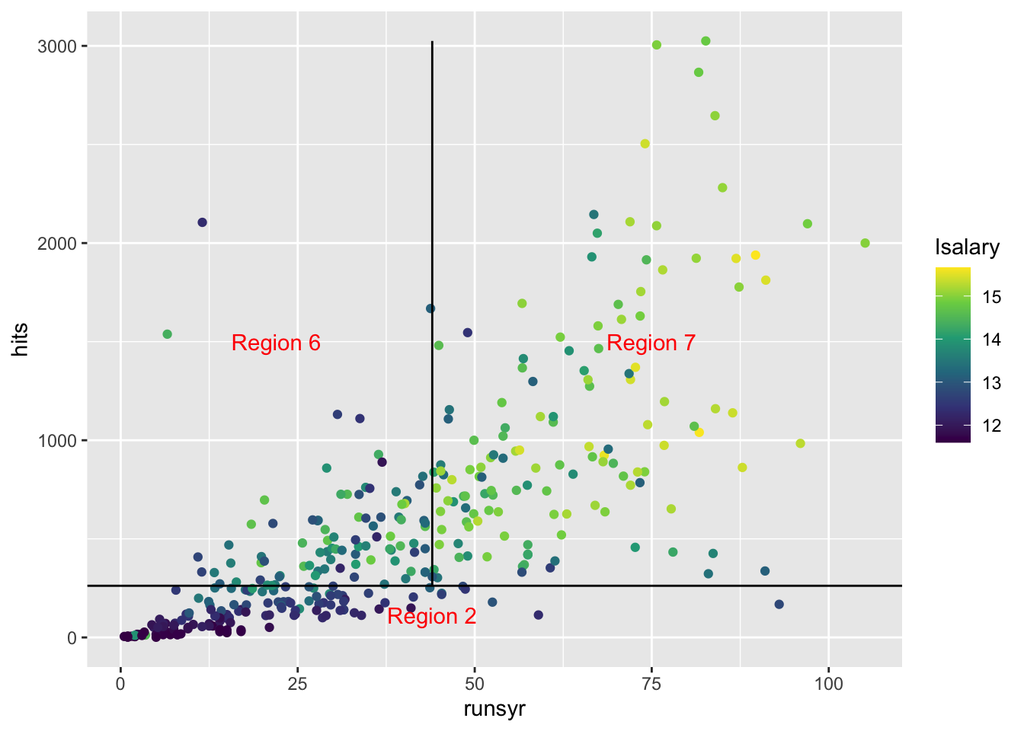

```r
ggplot(mlb1) +
  geom_point(aes(y = hits, x = runsyr, color = lsalary)) +
  scale_color_viridis_c() +
  geom_hline(yintercept = 262) +
  geom_line(
    data = data.table(x = 44, y = seq(262, max(mlb1$hits), length = 100)),
    aes(y = y, x = x)
  ) +
  annotate(
    "text",
    x = 44, y = 111,
    label = "Region 2",
    color = "red"
  ) +
  annotate(
    "text",
    x = 22, y = 1500,
    label = "Region 6",
    color = "red"
  ) +
  annotate(
    "text",
    x = 75, y = 1500,
    label = "Region 7",
    color = "red"
  )
```

The mechanism called recursive binary splitting is used to split the predictor space like the example above. Suppose you have K explanatory variables ($X_1, \dots, X_k$). Further, let $c$ denote the cutpoint that splits the sample into two regions: {$X|X_k < c$} and {$X|X_k \geq c$}.

{$X|X_k < c$} means observations that satisfy the condition stated right to the vertical bar (|). Here, it means all the observations for which its $X_k$ value is less than $c$.

- Step 1: For each of the explanatory variables ($X_1$ through $X_K$), find the cutpoint that leads to the lowest sum of the squared residuals.
- Step 2: Among all the splits (as many as the number of explanatory variables), pick the variable-cutpoint combination that leads to the lowest sum of the squared residuals.

The data is then split according to the chosen criteria and then the same process is repeated for each of the branches, ad infinitum until the user-specified stopping criteria is met.

Let’s try to write (an inefficient version) this process for illustration using a simple grid search to find the optimal cutpoints (Step 1) using the `mlb1` data.

```r
#=== get data ===#
library(wooldridge)
data(mlb1)

mlb1_dt <-
  mlb1 %>%
  data.table() %>%
  na.omit()
```

Let’s work on the splitting rule using `hruns`. First, we define a sequence of values of cutpoints for `hruns`.

```r
value_seq <-
  quantile(
    mlb1_dt$hruns,
    prob = seq(0.001, 0.999, length = 100)
  ) %>%
  unique()
```

For each value in `value_seq`, we find the RSS. For example, for the 50th value in `value_seq`,

```r
copy(mlb1_dt) %>%
  #=== find the mean of lsalary by whether hruns is less than the cutpoint or not ===#
  .[, y_hat := mean(lsalary), by = (hruns < value_seq[50])] %>%
  #=== get squared residuals ===#
  .[, (lsalary - y_hat)^2] %>%
  #=== get RSS ===#
  sum()
```

```
[1] 318.2431
```

How about 70th value in `value_seq`?

```r
copy(mlb1_dt) %>%
  #=== find the mean of lsalary by whether hruns is less than the cutpoint or not ===#
  .[, y_hat := mean(lsalary), by = (hruns < value_seq[70])] %>%
  #=== get squared residuals ===#
  .[, (lsalary - y_hat)^2] %>%
  #=== get RSS ===#
  sum()
```

```
[1] 419.1821
```

Okay, let’s consider all the candidate values, not just 50 and 70, and then pick the best.

```r
get_rss <- function(i, var_name, value_seq, data)
{
  rss <-
    copy(data) %>%
    setnames(var_name, "var") %>%
    .[, y_hat := mean(lsalary), by = (var < value_seq[i])] %>%
    .[, (lsalary - y_hat)^2] %>%
    sum()

  return_data <-
    data.table(
      rss = rss,
      var_name = var_name,
      var_value = value_seq[i]
    )

  return(return_data)
}
```

Here are RSS values at every value in `value_seq`.

```r
rss_value <-
  lapply(
    seq_len(length(value_seq)),
    function(x) get_rss(x, "hruns", value_seq, mlb1_dt)
  ) %>%
  rbindlist()

head(rss_value)
```

```
        rss var_name var_value
1: 445.0615    hruns         0
2: 396.8287    hruns         1
3: 383.2393    hruns         2
4: 362.5779    hruns         3
5: 337.0760    hruns         4
6: 325.4865    hruns         5
```

```r
tail(rss_value)
```

```
        rss var_name var_value
1: 419.1821    hruns  209.0881
2: 419.5111    hruns  231.0000
3: 428.4163    hruns  242.4425
4: 434.3318    hruns  258.5674
5: 441.9307    hruns  333.4414
6: 443.3740    hruns  426.0780
```

Finding the cutpoint value that minimizes RSS,

```r
rss_value[which.min(rss), ]
```

```
        rss var_name var_value
1: 260.3094    hruns  28.47488
```

Okay, so, the best cutpoint for `hruns` is 28.475

Suppose we are considering only five variables to include as explanatory variables in building a regression tree: `hruns`, `bavg`, `games`, `doubles`, and `rbis`. Then we do the same operation we did for `hruns` for all the variables.

```r
get_rss_by_var <- function(var_name, data)
{
  temp_data <- copy(data)

  #=== define a sequence of values of hruns ===#
  value_seq <-
    quantile(
      temp_data[, ..var_name] %>% unlist(),
      prob = seq(0.001, 0.999, length = 100)
    ) %>%
    unique()

  #=== get RSS ===#
  rss_value <-
    lapply(
      seq_len(length(value_seq)),
      function(x) get_rss(x, var_name, value_seq, temp_data)
    ) %>%
    rbindlist() %>%
    .[which.min(rss),]

  return(rss_value)
}
```

Looping over the set of variables,

```r
(
min_rss_by_var <-
  lapply(
    c("hruns", "bavg", "games", "doubles", "rbis"),
    function(x) get_rss_by_var(x, mlb1_dt)
  ) %>%
  rbindlist()
)
```

```
        rss var_name var_value
1: 260.3094    hruns  28.47488
2: 375.0281     bavg 252.35926
3: 213.4726    games 343.27876
4: 212.0808  doubles  41.40951
5: 208.9723     rbis 139.94219
```

So, the variable-cutpoint combination that minimizes RSS is rbis-139.9421919. We now have the first split. This tree is developed further by splitting nodes like this.

### Training a regression tree in R

You can fit a regression tree using `rpart()` from the `rpart` package. Its syntax is similar to that of `lm()` for a quick fitting.

```r
rpart(
  formula,
  data
)
```

Using `mlb1`, let’s fit a regression tree where the dependent variable is `lsalary` and all the other variable except `salary` is included.

```r
#=== fit a tree ===#
fitted_tree <-
  rpart(
    lsalary ~ . - salary,
    data = mlb1_dt
  )
```

Here is the visualization of the fitted tree using `fancyRpartPlot()` from the `rattle` package.

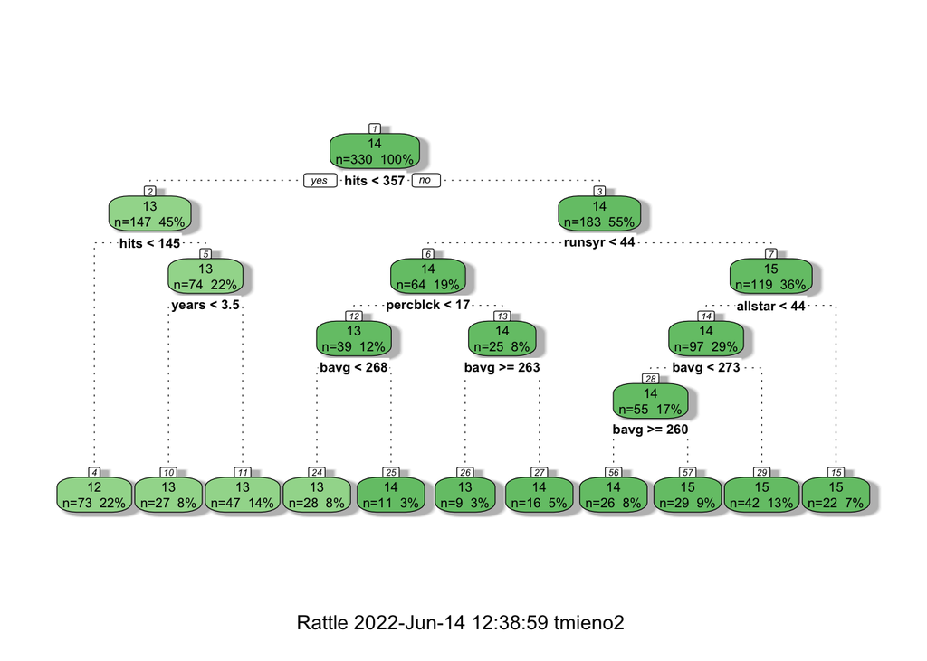

```r
fancyRpartPlot(fitted_tree)
```

Now, you may wonder why `rpart()` is not a building a tree where there are as many leaves as the number of observations so that we have a perfect prediction for the train data (`mlb1`). If we are implementing recursive binary splitting, then there is nothing for it to stop where it stopped. This is because `rpart()` sets parameters that control the development of a tree by default. Those default parameters can be seen below:

```r
rpart.control()
```

```
$minsplit
[1] 20

$minbucket
[1] 7

$cp
[1] 0.01

$maxcompete
[1] 4

$maxsurrogate
[1] 5

$usesurrogate
[1] 2

$surrogatestyle
[1] 0

$maxdepth
[1] 30

$xval
[1] 10
```

For example, `minsplit` is the minimum number of observations that must exist in a node in order for a split to be attempted. `cp` refers to the complexity parameter. For a given value of `cp`, a tree is build to minimize the following:

$$\sum_{t=1}^T\sum_{x_i\in R_t} (y_i - \hat{y_{R_t}})^2 + cp\cdot T$$

If you want to build a much more deep tree that has so many leaves, then you can do it using the `control` option like below.

```r
full_tree <-
  rpart(
    lsalary ~ . - salary, # formula
    data = mlb1_dt, # data
    control = # control of the hyper parameters
      rpart.control(
        minsplit = 2,
        cp = 0 # complexity parameter
      )
  )
```

Let’s see how amazing this tree is by comparing the observed and fitted `lsalary` values.

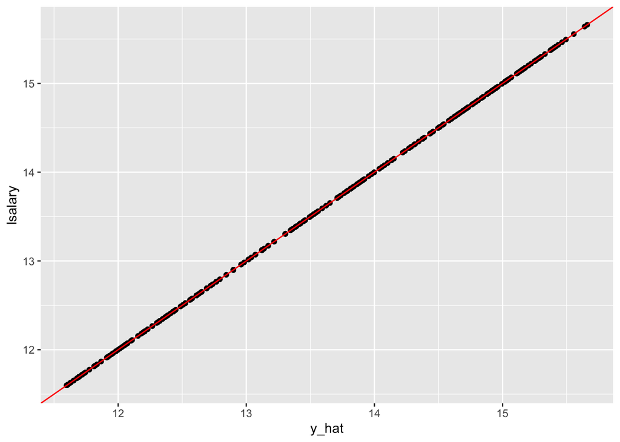

```r
#=== get fitted values ===#
mlb1_dt[, y_hat := predict(full_tree, newdata = mlb1_dt)]

#=== visualize the fit ===#
ggplot(data = mlb1_dt) +
  geom_point(aes(y = lsalary, x = y_hat)) +
  geom_abline(slope = 1, color = "red")
```

Yes, perfect prediction accuracy! At least for the train data anyway. But, we all know we want nothing to do with this kind of model. It is clearly over-fitting the train data.

In order to find a reasonable model, we can use KCV over `cp`. Fortunately, when we run `rpart()`, it automatically builds multiple trees at different values of `cp` that controls the number of leaves and conduct KCV. You can visualize this using `plotcp()`.

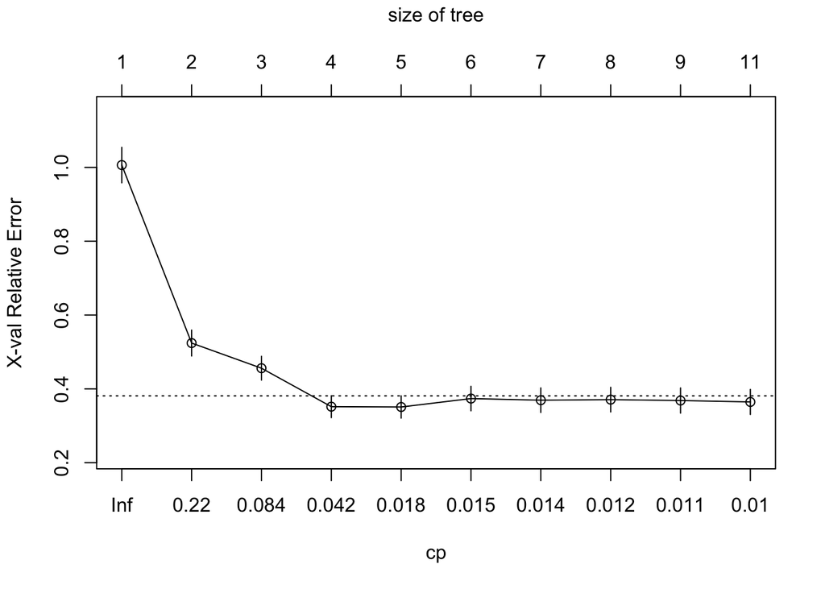

```r
plotcp(fitted_tree)
```

MSE and `cp` are presented on the y- and x-axis, respectively. According to the KCV results, `cp` $= 0.07$ provides the tree with the smallest number of leaves (the most simple) where the MSE value is within one standard deviation from the lowest MSE. You can access the tree built under `cp` $= 0.07$ like below.

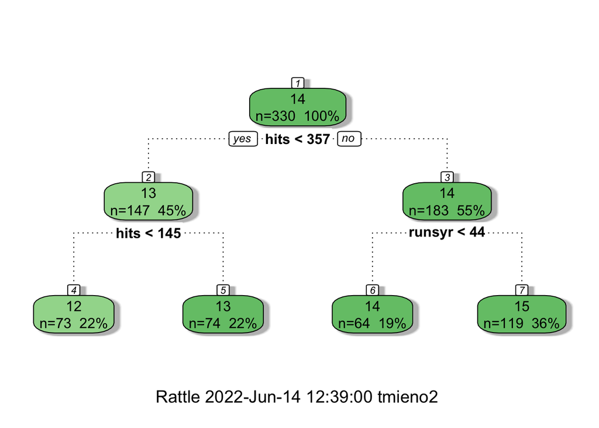

```r
#=== get the best tree ===#
best_tree <- prune(full_tree, cp = 0.07)

#=== visualize it ===#
fancyRpartPlot(best_tree)
```

Even though how a regression tree is build in R. In practice, you never use a regression tree itself as the final model for your research as its performance is rather poor and tend to over-fit compared to other competitive methods. But, understanding how building a regression tree is important to understand its derivatives like random forest, boosted regression forest.

## Random Forest (RF)

Regression tree approach is often not robust and suffers from high variance. Here, we look at the process called bagging and how it can be used to generate a model that is much more robust than a regression tree, which is called random forest.

### Bagging (Bootstrap aggregation)

Consider two random variables $x_1$ and $x_2$ from the identical distribution, where $E[x_i] = \alpha$ and $Var(x_i) = \sigma^2$. You are interested in estimating $E[x_i]$. We all know that the following relationship holds in general:

$$\begin{aligned}
Var(\frac{x_1 + x_2}{2}) & = \frac{Var(x_1)}{4} + \frac{Var(x_1)}{4} + \frac{Cov(x_1, x_2)}{2} \\
& = \frac{\sigma^2}{2} + \frac{Cov(x_1, x_2)}{2}
\end{aligned}$$

So, instead of using a single draw from $x_1$, and use it as an estimate for $E[x_i]$. It is better to use values from both $x_1$ and $x_2$ and average them to obtain an estimate for $E[x_i]$ as long as $x_1$ and $x_2$ are not perfectly positively correlated. The benefit of averaging is greater when the value of $Cov(x_1, x_2)$ is smaller.

Let’s do a little experiment to see this. We consider three cases:

```r
#=== set the number of observations to 1000 ===#
N <- 1000
```

```r
#=== first case (no correlation) ===#
x_1 <- rnorm(N)
x_2 <- rnorm(N)

cor(x_1, x_2)
```

```
[1] 0.02752261
```

```r
#=== second case (positively correlated) ===#
x_1 <- rnorm(N)
x_2 <- 0.8 * x_1 + sqrt(1-(0.8)^2) * rnorm(N)

cor(x_1, x_2)
```

```
[1] 0.8050598
```

```r
#=== third case (negatively correlated) ===#
x_1 <- rnorm(N)
x_2 <- - 0.8 * x_1 - sqrt(1-(0.8)^2) * rnorm(N)

cor(x_1, x_2)
```

```
[1] -0.7921021
```

```r
N <- 1

get_alpha <- function(i)
{
  #=== base case ===#
  alpha_hat_0 <- rnorm(1)

  #=== first case (no correlation) ===#
  x_1 <- rnorm(N)
  x_2 <- rnorm(N)

  alpha_hat_1 <- (x_1 + x_2) / 2

  #=== second case (positively correlated) ===#
  x_1 <- rnorm(N)
  x_2 <- 0.8 * x_1 + sqrt(1-(0.8)^2) * rnorm(N)

  alpha_hat_2 <- (x_1 + x_2) / 2

  #=== third case (negatively correlated) ===#
  x_1 <- rnorm(N)
  x_2 <- - 0.8 * x_1 - sqrt(1-(0.8)^2) * rnorm(N)

  alpha_hat_3 <- (x_1 + x_2) / 2

  return_data <-
    data.table(
      alpha_hat_0 = alpha_hat_0,
      alpha_hat_1 = alpha_hat_1,
      alpha_hat_2 = alpha_hat_2,
      alpha_hat_3 = alpha_hat_3
    )

  return(return_data)

}
```

```r
set.seed(234934)

sim_results <-
  lapply(
    1:1000,
    get_alpha
  ) %>%
  rbindlist() %>%
  melt()
```

As you can see, they are all pretty much unbiased. However, all the cases that averaged two values (cases 1, 2, and 3) outperformed the base case that relied on a single value each iteration. You can see that when the random variables are negatively correlated, the power of averaging is greater compared to when they are independent or positively correlated. The independent case (case 1) is better than the positive correlation case (case 2).

```r
#=== expected value ===#
sim_results[, mean(value), by = variable]
```

```
      variable          V1
1: alpha_hat_0 0.037836191
2: alpha_hat_1 0.008031971
3: alpha_hat_2 0.010264621
4: alpha_hat_3 0.004259832
```

```r
#=== standard error ===#
sim_results[, sd(value), by = variable]
```

```
      variable        V1
1: alpha_hat_0 0.9840232
2: alpha_hat_1 0.6969730
3: alpha_hat_2 0.9503372
4: alpha_hat_3 0.3103408
```

Bagging takes advantage of the power of averaging. Specifically, bagging takes the following steps:

- Generate many bootstrapped datasets (say $B$ datasets)
- Train a model on each of the bootstrapped datasets ($\hat{f}^1, \dots, \hat{f}^B$)
- Average the estimates from all the trained models to come up with an estimate

$$\hat{f}(X) = \frac{\hat{f}^1(X) + \dots + \hat{f}^B(X)}{B}$$

Let’s implement this for $B = 5$ using `mlb1_dt`.

```r
train_a_tree <- function(i, data)
{
  #=== number of observations ===#
  N <- nrow(data)

  #=== bootstrapped data ===#
  boot_data <- data[sample(1:N, N, replace = TRUE), ]

  #=== train a regression tree ===#
  rpart <-
    rpart(
      lsalary ~ . - salary,
      data = boot_data
    )

  #=== predict ===#
  return_data <-
    copy(data) %>%
    .[, y_hat := predict(rpart, newdata = data)] %>%
    .[, .(id, y_hat)]

  return(return_data)
}
```

```r
#=== create observation id for later ===#
mlb1_dt[, id := 1:.N]

(
y_estimates <-
  lapply(
    1:5,
    function(x) train_a_tree(x, mlb1_dt)
  ) %>%
  rbindlist()
)
```

```
       id    y_hat
   1:   1 15.04736
   2:   2 15.04736
   3:   3 15.04736
   4:   4 15.04736
   5:   5 14.06121
  ---
1646: 326 12.83884
1647: 327 12.37144
1648: 328 12.37144
1649: 329 12.37144
1650: 330 11.78869
```

By averaging $y$ estimates by `id`, we can get out bagging estimates.

```r
y_estimates[, mean(y_hat), by = id]
```

```
      id       V1
  1:   1 15.15782
  2:   2 14.97046
  3:   3 14.87708
  4:   4 14.87708
  5:   5 14.02839
 ---
326: 326 12.77870
327: 327 12.34913
328: 328 12.34913
329: 329 12.34913
330: 330 11.78819
```

Now, let’s take a look at the individual estimates of $y$ for the first observation.

```r
y_estimates[id == 1, ]
```

```
   id    y_hat
1:  1 15.04736
2:  1 15.29019
3:  1 15.21237
4:  1 15.31204
5:  1 14.92715
```

Hmm, the estimates look very similar. Actually, that is the case for all the observations. This is because the trained trees are very similar for many reasons, and the trees are highly “positively” correlated with each other. From our very simple experiment above, we know that the power of bagging is not very high when that is the case. While RF does use bagging, popular R and python packages does it in a much better way than I demonstrated here. We see this next.

### Random Forest (RF)

Unlike a naive bagging approach I demonstrated above, RF does it in a clever way to *decorrelate* trees. Specifically, for any leave of any tree they are building, they consider only a subset of all the explanatory variables when deciding how to split the leave where the selection of the set of variables happen randomly. A typical choice of the number of variables considered at each split is $\sqrt{K}$, where $K$ is the number of the explanatory variables specified by the user. In the naive example above, all $K$ variables are considered for all the split decisions of all the trees. Some variables are more influential than others and they get to be picked as the splitting variable at similar places. Instead, RF gives other variables a chance, which helps decorrelate the trees.

```r
#=== get variables names except salary ===#
(
var_list <- names(mlb1_dt) %>% .[!. %in% c("salary", "lsalary")]

)
```

```
 [1] "teamsal"  "nl"       "years"    "games"    "atbats"   "runs"
 [7] "hits"     "doubles"  "triples"  "hruns"    "rbis"     "bavg"
[13] "bb"       "so"       "sbases"   "fldperc"  "frstbase" "scndbase"
[19] "shrtstop" "thrdbase" "outfield" "catcher"  "yrsallst" "hispan"
[25] "black"    "whitepop" "blackpop" "hisppop"  "pcinc"    "gamesyr"
[31] "hrunsyr"  "atbatsyr" "allstar"  "slugavg"  "rbisyr"   "sbasesyr"
[37] "runsyr"   "percwhte" "percblck" "perchisp" "blckpb"   "hispph"
[43] "whtepw"   "blckph"   "hisppb"   "y_hat"    "id"
```

We will use the following numbers of variables in each splitting decision.

```r
(
num_var_split <-
  var_list %>%
  length() %>%
  sqrt() %>%
  floor()
)
```

```
[1] 6
```

Let’s get a bootstrapped dataset.

```r
#=== number of observations ===#
N <- nrow(mlb1_dt)

#=== bootstrapped data ===#
(
boot_data <- mlb1_dt[sample(1:N, N, replace = TRUE), ]
)
```

```
      salary  teamsal nl years games atbats runs hits doubles triples hruns
  1:  118000 22840832  0     1    47    133   17   30       3       1     2
  2:  400000 37226584  0     8   825   2361  294  610      84      20    43
  3: 2000000 18297546  1     2    45     66    7   12       1       0     1
  4:  435000 36217500  1     2   163    559   63  141      31       1    20
  5:  400000 27396932  0     9  1044   3290  380  774     165      14   121
 ---
326:  312500 26958972  0     3   267    898  105  224      41       2    33
327:  500000 35228168  0     6   722   2794  440  785     160      27    93
328:  300000 36217500  1     3   230    705   84  170      22       8     2
329: 2187500 31580834  0    11  1495   5227  624 1367     247      21   162
330: 3666667 39776560  0    10  1140   3386  452  844     183      35    69
     rbis bavg  bb  so sbases fldperc frstbase scndbase shrtstop thrdbase
  1:   10  226  12  30     10    1000        1        0        0        0
  2:  264  258 224 369     19     963        0        0        1        0
```

[output cut: 57 more lines]

We can use `ranger()` from the `ranger` package to train an RF model using the same data.

Another compelling R package for RF is the `randomForest` package.

The `ranger()` function has many options you can specify that determine how trees are built. Here are some of the important onesv (see [here](https://cran.r-project.org/web/packages/ranger/ranger.pdf) for the complete description of the hyper-parameters.):

- `mtry`: the number of variables considered in each split (default is the square root of the total numbers of explanatory variables rounded down.)
- `num.trees`: the number of tree to be built (default is 500)
- `min.node.size`: minimum number of observations in each node (default varies based on the the type of analysis)
- `replace`: where sample with or without replacement when bootstrapping samples (default is `TRUE`)
- `sample.fraction`: the fraction of the entire observations that are used in each tree (default is 1 if sampling with replacement, 0.632 if sampling without replacement)

Let’s try fitting an RF with `ranger()` with the default parameters.

```r
#=== load the package ===#
library(ranger)
#=== fit and RF ===#
(
rf_fit <- ranger(lsalary ~ . - salary, data = mlb1_dt)
)
```

```
Ranger result

Call:
 ranger(lsalary ~ . - salary, data = mlb1_dt)

Type:                             Regression
Number of trees:                  500
Sample size:                      330
Number of independent variables:  47
Mtry:                             6
Target node size:                 5
Variable importance mode:         none
Splitrule:                        variance
OOB prediction error (MSE):       0.1243536
R squared (OOB):                  0.9080749
```

Since we have many trees, it is no longer possible to have a nice graphical representation of the model like we did with a regression tree.

In the output, you can see `OOB prediction error (MSE)`. OOB stands for out-of-bag. When bootstrapping (whether you do it with replacement or not), some of the train data will not be used to build a tree.

```r
n_obs <- nrow(mlb1_dt)

#=== bootstrapped data ===#
boot_data <- mlb1_dt[sample(1:n_obs, n_obs, replace = TRUE), ]

#=== which rows (observations) from the original datasets are missing? ===#
mlb1_dt[, id %in% unique(boot_data$id)] %>% mean()
```

```
[1] 0.630303
```

You can use a simple grid-search to find the best hyper-parameters. Grid-search is simply a brute-force optimization methods that goes through all the combinations of hyper-parameters and see which combination comes at the top. The computational intensity of grid-search depends on how many hyper-parameters you want to vary and how many values you would like to look at for each of the hyper-parameters. Here, let’s tune `mtry`, `min.node.size`, and `sample.fraction`.

```r
#=== define set of values you want to look at ===#
mtry_seq <- c(3, 5, 8)
min_node_size_seq <- c(2, 5, 10)
sample_fraction_seq <- c(0.5, 0.75, 1)

#=== create a complete combinations of the three parameters ===#
(
parameters <-
  data.table::CJ(
    mtry = mtry_seq,
    min_node_size = min_node_size_seq,
    sample_fraction = sample_fraction_seq
  )
)
```

```
    mtry min_node_size sample_fraction
 1:    3             2            0.50
 2:    3             2            0.75
 3:    3             2            1.00
 4:    3             5            0.50
 5:    3             5            0.75
 6:    3             5            1.00
 7:    3            10            0.50
 8:    3            10            0.75
 9:    3            10            1.00
10:    5             2            0.50
11:    5             2            0.75
12:    5             2            1.00
13:    5             5            0.50
14:    5             5            0.75
15:    5             5            1.00
16:    5            10            0.50
17:    5            10            0.75
18:    5            10            1.00
19:    8             2            0.50
20:    8             2            0.75
21:    8             2            1.00
22:    8             5            0.50
23:    8             5            0.75
24:    8             5            1.00
25:    8            10            0.50
26:    8            10            0.75
27:    8            10            1.00
    mtry min_node_size sample_fraction
```

In total, we have 27 ($3 \times 3 \times 3$) cases. You can see how quickly the number of cases increases as you increase the number of parameters to tune and the values of each parameter. We can now loop over the rows of this parameter data (`parameters`) and get OOB MSE for each of them.

```r
oob_mse_all <-
  lapply(
    seq_len(nrow(parameters)),
    function(x) {

      #=== Fit the mode ===#
      rf_fit <-
        ranger(
          lsalary ~ . - salary,
          data = mlb1_dt,
          num.trees = 1000,
          mtry = parameters[x, mtry],
          min.node.size = parameters[x, min_node_size],
          sample.fraction = parameters[x, sample_fraction]
        )

      #=== return OOB SME ===#
      return(rf_fit$prediction.error)

    }
  ) %>%
  unlist()

parameters[, oob_mse := oob_mse_all]

parameters
```

```
    mtry min_node_size sample_fraction    oob_mse
 1:    3             2            0.50 0.23836601
 2:    3             2            0.75 0.22770773
 3:    3             2            1.00 0.21723253
 4:    3             5            0.50 0.23899880
 5:    3             5            0.75 0.21729963
 6:    3             5            1.00 0.22696406
 7:    3            10            0.50 0.24980598
 8:    3            10            0.75 0.23827242
 9:    3            10            1.00 0.22215357
10:    5             2            0.50 0.17664862
11:    5             2            0.75 0.16172460
12:    5             2            1.00 0.15306268
13:    5             5            0.50 0.17509478
14:    5             5            0.75 0.15767473
15:    5             5            1.00 0.15557055
16:    5            10            0.50 0.18690883
17:    5            10            0.75 0.16871739
18:    5            10            1.00 0.16044891
19:    8             2            0.50 0.11506374
20:    8             2            0.75 0.10483909
21:    8             2            1.00 0.09480448
22:    8             5            0.50 0.12113384
23:    8             5            0.75 0.10536723
24:    8             5            1.00 0.09736831
25:    8            10            0.50 0.13080278
26:    8            10            0.75 0.10961714
27:    8            10            1.00 0.10113742
    mtry min_node_size sample_fraction    oob_mse
```

So, the best choice among the ones tried is:

```r
parameters[which.min(oob_mse), ]
```

```
   mtry min_node_size sample_fraction    oob_mse
1:    8             2               1 0.09480448
```

### Boosting

In training RF that uses the idea of bagging, the original data is used to generate many bootstrapped datasets, a regression tree is trained on each of them independently , and then they are averaged to reach the final model. Boosting is similar to bagging (bootstrap aggregation) in that it trains many statistical models and then combine them to reach the final model. However, instead of building many trees independently, it builds trees sequentially in a manner that improves prediction step by step.

While there are many variants of boosting methods (see Chapter 10 of @hastie2009elements), we will look at gradient boosting using trees for regression in particular (Algorithm 10.3 in @hastie2009elements presents the generic gradient tree boosting algorithm), where squared error is used as the loss function.